# Part 1: Data Exploration (EDA):

**Introduction:** In this lab, the activity will examine the relationship between Body Mass Index and diabetes progression using the Diabetes dataset from scikit-learn. The dataset is split into training (75%), validation (10%), and test (15%) sets. The lab will fit polynomial regression models of various degrees with differnt feature to predict disease progression. Finally evaluating model on all sets to assess the effectiveness of each polynomial degree.

Source:[Diabetes dataset](https://scikit-learn.org/stable/datasets/toy_dataset.html#diabetes-dataset)

**Describtion**

```python
import pandas as pd
import numpy as np
import matplotlib.pyplot as plt
import seaborn as sns
from sklearn.datasets import load_diabetes


diabetes_data = load_diabetes()
diabetes_df = pd.DataFrame(data=diabetes_data.data, columns=diabetes_data.feature_names)
diabetes_df['target'] = diabetes_data.target
diabetes_df.head()
```

|  | age | sex | bmi | bp | s1 | s2 | s3 | s4 | s5 | s6 | target |
| --- | --- | --- | --- | --- | --- | --- | --- | --- | --- | --- | --- |
| 0 | 0.038076 | 0.050680 | 0.061696 | 0.021872 | -0.044223 | -0.034821 | -0.043401 | -0.002592 | 0.019907 | -0.017646 | 151.0 |
| 1 | -0.001882 | -0.044642 | -0.051474 | -0.026328 | -0.008449 | -0.019163 | 0.074412 | -0.039493 | -0.068332 | -0.092204 | 75.0 |
| 2 | 0.085299 | 0.050680 | 0.044451 | -0.005670 | -0.045599 | -0.034194 | -0.032356 | -0.002592 | 0.002861 | -0.025930 | 141.0 |
| 3 | -0.089063 | -0.044642 | -0.011595 | -0.036656 | 0.012191 | 0.024991 | -0.036038 | 0.034309 | 0.022688 | -0.009362 | 206.0 |
| 4 | 0.005383 | -0.044642 | -0.036385 | 0.021872 | 0.003935 | 0.015596 | 0.008142 | -0.002592 | -0.031988 | -0.046641 | 135.0 |

**Statistics**

```python
diabetes_df.info()

diabetes_df.describe()
```

```
<class 'pandas.core.frame.DataFrame'>
RangeIndex: 442 entries, 0 to 441
Data columns (total 11 columns):
 #   Column  Non-Null Count  Dtype
---  ------  --------------  -----
 0   age     442 non-null    float64
 1   sex     442 non-null    float64
 2   bmi     442 non-null    float64
 3   bp      442 non-null    float64
 4   s1      442 non-null    float64
 5   s2      442 non-null    float64
 6   s3      442 non-null    float64
 7   s4      442 non-null    float64
 8   s5      442 non-null    float64
 9   s6      442 non-null    float64
 10  target  442 non-null    float64
dtypes: float64(11)
memory usage: 38.1 KB
```

|  | age | sex | bmi | bp | s1 | s2 | s3 | s4 | s5 | s6 | target |
| --- | --- | --- | --- | --- | --- | --- | --- | --- | --- | --- | --- |
| count | 4.420000e+02 | 4.420000e+02 | 4.420000e+02 | 4.420000e+02 | 4.420000e+02 | 4.420000e+02 | 4.420000e+02 | 4.420000e+02 | 4.420000e+02 | 4.420000e+02 | 442.000000 |
| mean | -2.511817e-19 | 1.230790e-17 | -2.245564e-16 | -4.797570e-17 | -1.381499e-17 | 3.918434e-17 | -5.777179e-18 | -9.042540e-18 | 9.293722e-17 | 1.130318e-17 | 152.133484 |
| std | 4.761905e-02 | 4.761905e-02 | 4.761905e-02 | 4.761905e-02 | 4.761905e-02 | 4.761905e-02 | 4.761905e-02 | 4.761905e-02 | 4.761905e-02 | 4.761905e-02 | 77.093005 |
| min | -1.072256e-01 | -4.464164e-02 | -9.027530e-02 | -1.123988e-01 | -1.267807e-01 | -1.156131e-01 | -1.023071e-01 | -7.639450e-02 | -1.260971e-01 | -1.377672e-01 | 25.000000 |
| 25% | -3.729927e-02 | -4.464164e-02 | -3.422907e-02 | -3.665608e-02 | -3.424784e-02 | -3.035840e-02 | -3.511716e-02 | -3.949338e-02 | -3.324559e-02 | -3.317903e-02 | 87.000000 |
| 50% | 5.383060e-03 | -4.464164e-02 | -7.283766e-03 | -5.670422e-03 | -4.320866e-03 | -3.819065e-03 | -6.584468e-03 | -2.592262e-03 | -1.947171e-03 | -1.077698e-03 | 140.500000 |
| 75% | 3.807591e-02 | 5.068012e-02 | 3.124802e-02 | 3.564379e-02 | 2.835801e-02 | 2.984439e-02 | 2.931150e-02 | 3.430886e-02 | 3.243232e-02 | 2.791705e-02 | 211.500000 |
| max | 1.107267e-01 | 5.068012e-02 | 1.705552e-01 | 1.320436e-01 | 1.539137e-01 | 1.987880e-01 | 1.811791e-01 | 1.852344e-01 | 1.335973e-01 | 1.356118e-01 | 346.000000 |

**Histogram** Here are the histograms, each one shows the distribution of a variable.

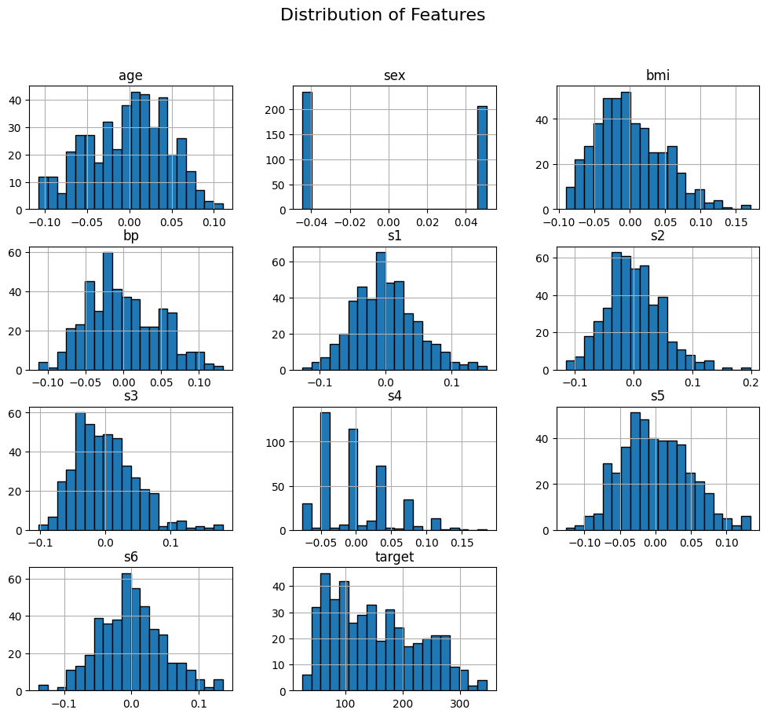

```python
diabetes_df.hist(bins=20, figsize=(12, 10), edgecolor='black')
plt.suptitle('Distribution of Features', size=16)
plt.show()
```

**Correlation matrix**

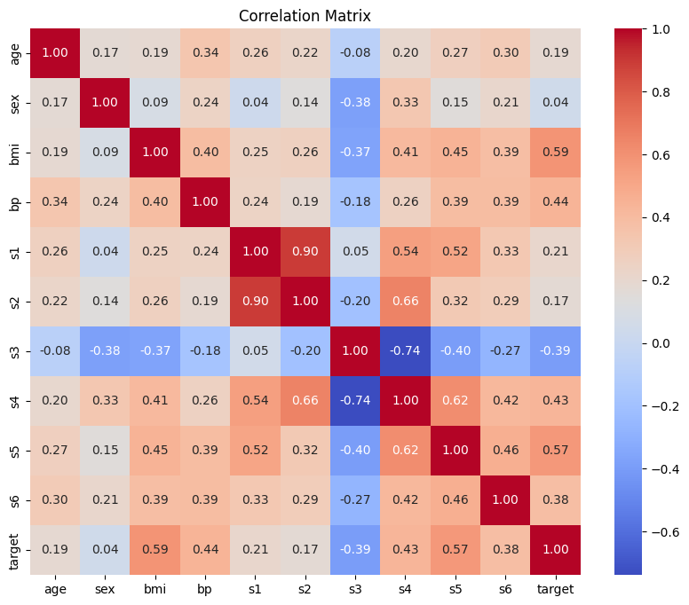

```python
corr_matrix = diabetes_df.corr()
plt.figure(figsize=(10, 8))
sns.heatmap(corr_matrix, annot=True, cmap='coolwarm', fmt='.2f')
plt.title('Correlation Matrix')
plt.show()
```

**Scatter plot matrix.**

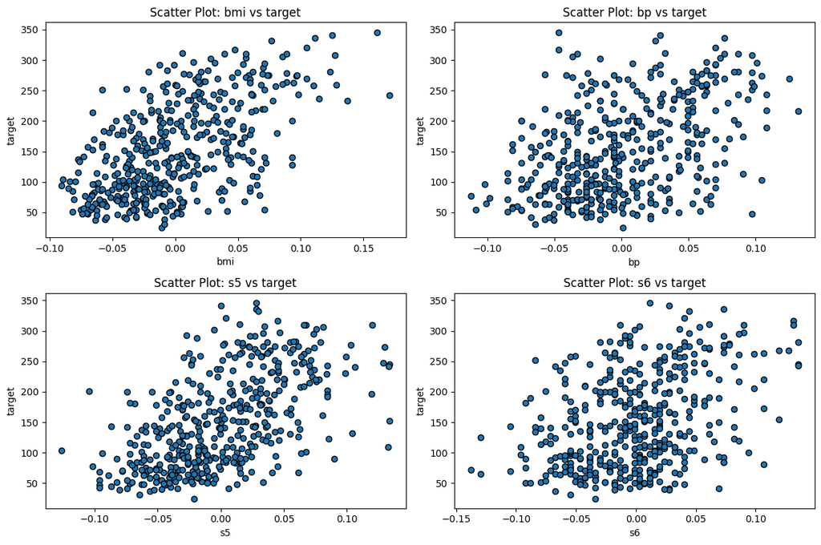

```python
features_to_plot = ['bmi', 'bp', 's5', 's6']
plt.figure(figsize=(12, 8))
for i, feature in enumerate(features_to_plot, 1):
    plt.subplot(2, 2, i)
    plt.scatter(diabetes_df[feature], diabetes_df['target'], edgecolor='k')
    plt.title(f'Scatter Plot: {feature} vs target')
    plt.xlabel(feature)
    plt.ylabel('target')
plt.tight_layout()
plt.show()
```

**Clean the data** It seems there are no missing values, there no need to clean.

```python
missing_values = diabetes_df.isnull().sum()
print(f"Missing values in each column:\n{missing_values}")
```

```
Missing values in each column:
age       0
sex       0
bmi       0
bp        0
s1        0
s2        0
s3        0
s4        0
s5        0
s6        0
target    0
dtype: int64
```

**Split the dataset**

```python
from sklearn.model_selection import train_test_split


X = diabetes_df.drop('target', axis=1)
y = diabetes_df['target']


X_train_val, X_test, y_train_val, y_test = train_test_split(X, y, test_size=0.15, random_state=42)


X_train, X_val, y_train, y_val = train_test_split(X_train_val, y_train_val, test_size=0.12, random_state=42)

print(f"Training set size: {X_train.shape[0]}")
print(f"Validation set size: {X_val.shape[0]}")
print(f"Test set size: {X_test.shape[0]}")
```

```
Training set size: 330
Validation set size: 45
Test set size: 67
```

# Part 2 : Modeling

```python
from sklearn.preprocessing import PolynomialFeatures
from sklearn.linear_model import LinearRegression
from sklearn.metrics import mean_squared_error


X_train_bmi = X_train[['bmi']]
X_val_bmi = X_val[['bmi']]
X_test_bmi = X_test[['bmi']]
y_train_bmi = y_train
y_val_bmi = y_val
y_test_bmi = y_test

models = {}



for degree in range(6):

    poly = PolynomialFeatures(degree=degree)
    X_train_poly = poly.fit_transform(X_train_bmi)
    model = LinearRegression()
    model.fit(X_train_poly, y_train_bmi)
    models[degree] = model
    y_train_pred = model.predict(X_train_poly)
```

Evaluation

```python
from sklearn.metrics import r2_score, mean_absolute_error


results = []


for degree, model in models.items():
    poly = PolynomialFeatures(degree=degree)


    X_train_poly = poly.fit_transform(X_train_bmi)
    X_val_poly = poly.transform(X_val_bmi)


    y_train_pred = model.predict(X_train_poly)
    y_val_pred = model.predict(X_val_poly)


    train_r2 = r2_score(y_train_bmi, y_train_pred)
    val_r2 = r2_score(y_val_bmi, y_val_pred)

    train_mae = mean_absolute_error(y_train_bmi, y_train_pred)
    val_mae = mean_absolute_error(y_val_bmi, y_val_pred)


    train_mape = np.mean(np.abs((y_train_bmi - y_train_pred) / y_train_bmi)) * 100
    val_mape = np.mean(np.abs((y_val_bmi - y_val_pred) / y_val_bmi)) * 100


    results.append({
        'Degree': degree,
        'Train R²': train_r2,
        'Validation R²': val_r2,
        'Train MAE': train_mae,
        'Validation MAE': val_mae,
        'Train MAPE (%)': train_mape,
        'Validation MAPE (%)': val_mape
    })


results_df = pd.DataFrame(results)

print("Polynomial Model Comparison")
print(results_df)


results_df.style.set_caption("Polynomial Model Comparison").format({
    'Train R²': "{:.4f}",
    'Validation R²': "{:.4f}",
    'Train MAE': "{:.2f}",
    'Validation MAE': "{:.2f}",
    'Train MAPE (%)': "{:.2f}",
    'Validation MAPE (%)': "{:.2f}"
})
```

```
Polynomial Model Comparison
   Degree  Train R²  Validation R²  Train MAE  Validation MAE  Train MAPE (%)  \
0       0  0.000000      -0.000011  66.548209       63.447475       63.352070
1       1  0.354240       0.449292  52.278064       41.997581       48.462384
2       2  0.354771       0.449158  52.267273       41.757683       48.447858
3       3  0.355002       0.447291  52.223375       41.741042       48.356420
4       4  0.357983       0.449064  51.944372       41.952846       47.963501
5       5  0.358910       0.453513  51.813830       42.083400       47.831494

   Validation MAPE (%)
0            58.793283
1            40.444999
2            40.309938
3            40.258961
4            40.240642
5            40.340475
```

Polynomial Model Comparison

|  | Degree | Train R² | Validation R² | Train MAE | Validation MAE | Train MAPE (%) | Validation MAPE (%) |
| --- | --- | --- | --- | --- | --- | --- | --- |
| 0 | 0 | 0.0000 | -0.0000 | 66.55 | 63.45 | 63.35 | 58.79 |
| 1 | 1 | 0.3542 | 0.4493 | 52.28 | 42.00 | 48.46 | 40.44 |
| 2 | 2 | 0.3548 | 0.4492 | 52.27 | 41.76 | 48.45 | 40.31 |
| 3 | 3 | 0.3550 | 0.4473 | 52.22 | 41.74 | 48.36 | 40.26 |
| 4 | 4 | 0.3580 | 0.4491 | 51.94 | 41.95 | 47.96 | 40.24 |
| 5 | 5 | 0.3589 | 0.4535 | 51.81 | 42.08 | 47.83 | 40.34 |

The best model is a balance between having a high R² and low MAE/MAPE. According to the result, the polynomial model of degree 5 has the highest Validation R² and comparable MAE/MAPE values to other degrees. And the polynomial of degree 3 or 4 might be preferable due to slightly lower MAE/MAPE.

```python
from sklearn.metrics import r2_score, mean_absolute_error


degree = 5
model = models[degree]


poly = PolynomialFeatures(degree=degree)
X_test_poly = poly.fit_transform(X_test_bmi)


y_test_pred = model.predict(X_test_poly)


test_r2 = r2_score(y_test_bmi, y_test_pred)
test_mae = mean_absolute_error(y_test_bmi, y_test_pred)
test_mape = np.mean(np.abs((y_test_bmi - y_test_pred) / y_test_bmi)) * 100


print(f"Results for Degree {degree} on the Test Set:")
print(f"R-Squared: {test_r2:.4f}")
print(f"Mean Absolute Error (MAE): {test_mae:.4f}")
print(f"Mean Absolute Percentage Error (MAPE): {test_mape:.2f}%")
```

```
Results for Degree 5 on the Test Set:
R-Squared: 0.1973
Mean Absolute Error (MAE): 54.5484
Mean Absolute Percentage Error (MAPE): 47.88%
```

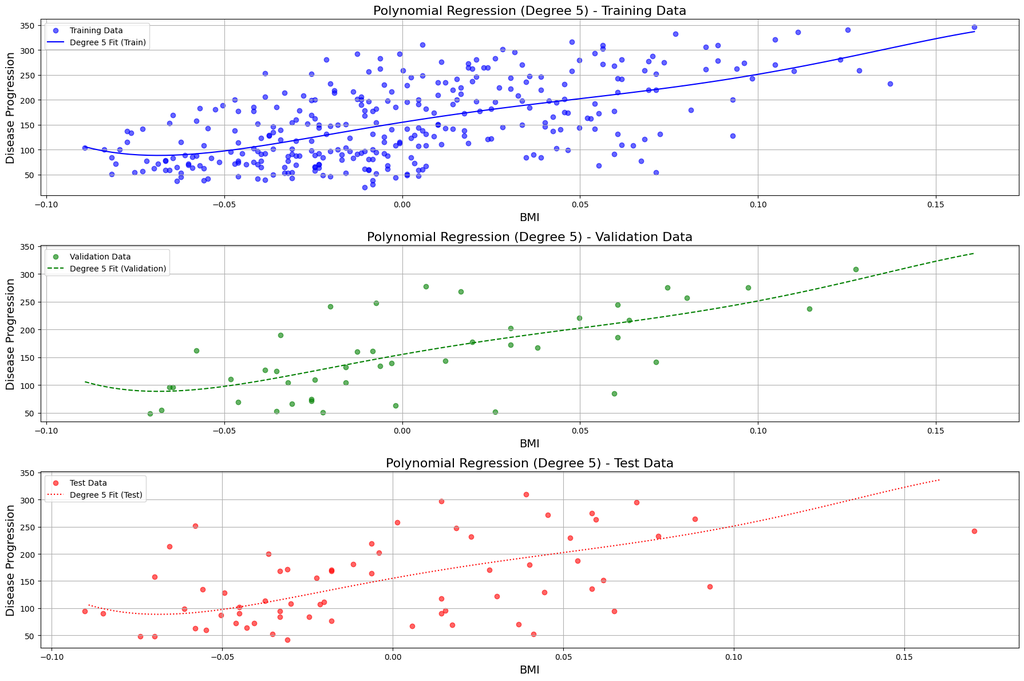

```python
import numpy as np
import matplotlib.pyplot as plt


degree = 5
model = models[degree]


poly = PolynomialFeatures(degree=degree)
X_train_poly = poly.fit_transform(X_train_bmi)
X_val_poly = poly.transform(X_val_bmi)
X_test_poly = poly.transform(X_test_bmi)


y_train_pred = model.predict(X_train_poly)
y_val_pred = model.predict(X_val_poly)
y_test_pred = model.predict(X_test_poly)

X_plot = np.linspace(X_train_bmi.min(), X_train_bmi.max(), 100).reshape(-1, 1)
X_plot_poly = poly.transform(X_plot)


y_plot_pred = model.predict(X_plot_poly)


plt.figure(figsize=(18, 12))


plt.subplot(3, 1, 1)
plt.scatter(X_train_bmi, y_train_bmi, color='blue', label='Training Data', alpha=0.6)
plt.plot(X_plot, y_plot_pred, color='blue', linestyle='-', label='Degree 5 Fit (Train)')
plt.title('Polynomial Regression (Degree 5) - Training Data', fontsize=16)
plt.xlabel('BMI', fontsize=14)
plt.ylabel('Disease Progression', fontsize=14)
plt.legend()
plt.grid(True)


plt.subplot(3, 1, 2)
plt.scatter(X_val_bmi, y_val_bmi, color='green', label='Validation Data', alpha=0.6)
plt.plot(X_plot, y_plot_pred, color='green', linestyle='--', label='Degree 5 Fit (Validation)')
plt.title('Polynomial Regression (Degree 5) - Validation Data', fontsize=16)
plt.xlabel('BMI', fontsize=14)
plt.ylabel('Disease Progression', fontsize=14)
plt.legend()
plt.grid(True)

plt.subplot(3, 1, 3)
plt.scatter(X_test_bmi, y_test_bmi, color='red', label='Test Data', alpha=0.6)
plt.plot(X_plot, y_plot_pred, color='red', linestyle=':', label='Degree 5 Fit (Test)')
plt.title('Polynomial Regression (Degree 5) - Test Data', fontsize=16)
plt.xlabel('BMI', fontsize=14)
plt.ylabel('Disease Progression', fontsize=14)
plt.legend()
plt.grid(True)


plt.tight_layout()
plt.show()
```

```python
degree = 5
model = models[degree]


poly = PolynomialFeatures(degree=degree)

X_train_poly = poly.fit_transform(X_train_bmi)

coefficients = model.coef_
intercept = model.intercept_


equation_terms = [f"{intercept:.2f}"]


for i in range(1, len(coefficients)):
    equation_terms.append(f"{coefficients[i]:.2f} * x^{i}")


equation = " + ".join(equation_terms)

print(f"Degree {degree} Polynomial Regression Equation:")
print(f"y = {equation}")
```

```
Degree 5 Polynomial Regression Equation:
y = 155.08 + 1131.59 * x^1 + -3946.02 * x^2 + -26110.86 * x^3 + 768725.87 * x^4 + -2823251.97 * x^5
```

```python
bmi_value = 0.03

bmi_poly = poly.transform(np.array([[bmi_value]]))

predicted_progression = model.predict(bmi_poly)

print(f"Predicted diabetes progression for BMI = {bmi_value}: {predicted_progression[0]:.2f}")
```

```
Predicted diabetes progression for BMI = 0.03: 185.33
```

```python
from sklearn.preprocessing import PolynomialFeatures

for degree, model in models.items():
    poly = PolynomialFeatures(degree=degree)


    poly.fit(np.array([[0]]))

    feature_names = poly.get_feature_names_out(['bmi'])

    num_trainable_params = len(feature_names)
    print(f"Degree {degree} model has {num_trainable_params} trainable parameters:")
    print(feature_names)
    print()
```

```
Degree 0 model has 1 trainable parameters:
['1']

Degree 1 model has 2 trainable parameters:
['1' 'bmi']

Degree 2 model has 3 trainable parameters:
['1' 'bmi' 'bmi^2']

Degree 3 model has 4 trainable parameters:
['1' 'bmi' 'bmi^2' 'bmi^3']

Degree 4 model has 5 trainable parameters:
['1' 'bmi' 'bmi^2' 'bmi^3' 'bmi^4']

Degree 5 model has 6 trainable parameters:
['1' 'bmi' 'bmi^2' 'bmi^3' 'bmi^4' 'bmi^5']
```

# Conclusions

In conclusion, the degree 5 polynomial regression model did best on the training data. While higher-degree models capture complex relationships, they tend to fit the noise in the data, reducing their ability to generalize to unseen data.

# Part 3

```python
from sklearn.metrics import r2_score, mean_absolute_error
from sklearn.preprocessing import PolynomialFeatures
from sklearn.linear_model import LinearRegression
import pandas as pd
import numpy as np


models = {}


for degree in [3, 5]:
    poly = PolynomialFeatures(degree=degree)
    X_train_poly = poly.fit_transform(X_train)

    model = LinearRegression()
    model.fit(X_train_poly, y_train)

    models[degree] = model


results = []


for degree, model in models.items():
    poly = PolynomialFeatures(degree=degree)


    X_train_poly = poly.fit_transform(X_train)
    X_val_poly = poly.transform(X_val)


    y_train_pred = model.predict(X_train_poly)
    y_val_pred = model.predict(X_val_poly)


    train_r2 = r2_score(y_train, y_train_pred)
    val_r2 = r2_score(y_val, y_val_pred)

    train_mae = mean_absolute_error(y_train, y_train_pred)
    val_mae = mean_absolute_error(y_val, y_val_pred)

    train_mape = np.mean(np.abs((y_train - y_train_pred) / y_train)) * 100
    val_mape = np.mean(np.abs((y_val - y_val_pred) / y_val)) * 100


    results.append({
        'Degree': degree,
        'Train R²': train_r2,
        'Validation R²': val_r2,
        'Train MAE': train_mae,
        'Validation MAE': val_mae,
        'Train MAPE (%)': train_mape,
        'Validation MAPE (%)': val_mape
    })


results_df = pd.DataFrame(results)


print("Polynomial Model Comparison")
print(results_df)


results_df.style.set_caption("Polynomial Model Comparison").format({
    'Train R²': "{:.4f}",
    'Validation R²': "{:.4f}",
    'Train MAE': "{:.2f}",
    'Validation MAE': "{:.2f}",
    'Train MAPE (%)': "{:.2f}",
    'Validation MAPE (%)': "{:.2f}"
})
```

```
Polynomial Model Comparison
   Degree  Train R²  Validation R²     Train MAE  Validation MAE  \
0       3  0.473186    -127.985803  4.517879e+01      378.755556
1       5  1.000000     -29.285061  1.882344e-11      307.415793

   Train MAPE (%)  Validation MAPE (%)
0    4.048364e+01           261.736810
1    1.634658e-11           262.904124
```

Polynomial Model Comparison

|  | Degree | Train R² | Validation R² | Train MAE | Validation MAE | Train MAPE (%) | Validation MAPE (%) |
| --- | --- | --- | --- | --- | --- | --- | --- |
| 0 | 3 | 0.4732 | -127.9858 | 45.18 | 378.76 | 40.48 | 261.74 |
| 1 | 5 | 1.0000 | -29.2851 | 0.00 | 307.42 | 0.00 | 262.90 |

```python
degree_5_model = models[5]

poly_5 = PolynomialFeatures(degree=5)
X_test_poly = poly_5.fit_transform(X_test)


y_test_pred = degree_5_model.predict(X_test_poly)


test_r2 = r2_score(y_test, y_test_pred)
test_mae = mean_absolute_error(y_test, y_test_pred)
test_mape = np.mean(np.abs((y_test - y_test_pred) / y_test)) * 100

print(f"Degree 5 Polynomial Regression - Test R²: {test_r2:.4f}")
print(f"Degree 5 Polynomial Regression - Test MAE: {test_mae:.2f}")
print(f"Degree 5 Polynomial Regression - Test MAPE: {test_mape:.2f}%")
```

```
Degree 5 Polynomial Regression - Test R²: -22.8166
Degree 5 Polynomial Regression - Test MAE: 256.25
Degree 5 Polynomial Regression - Test MAPE: 227.61%
```

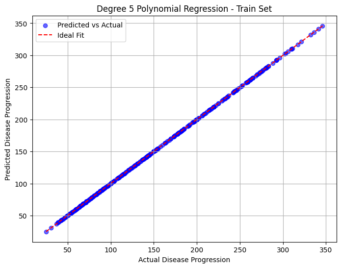

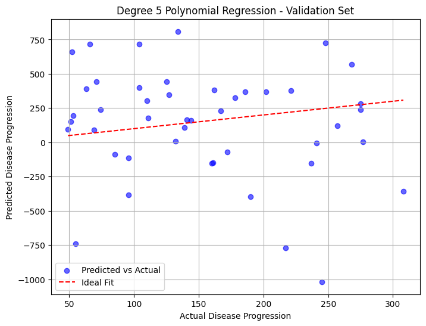

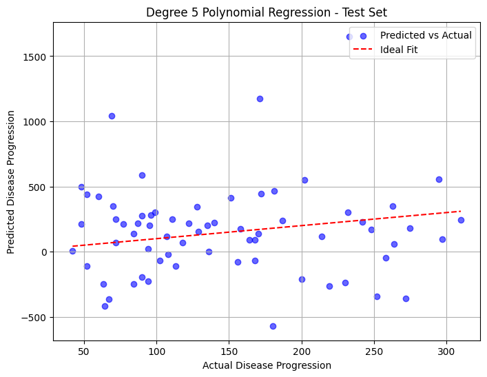

```python
import matplotlib.pyplot as plt


def plot_actual_vs_predicted(y_actual, y_pred, title):
    plt.figure(figsize=(8, 6))
    plt.scatter(y_actual, y_pred, color='blue', label='Predicted vs Actual', alpha=0.6)
    plt.plot([y_actual.min(), y_actual.max()], [y_actual.min(), y_actual.max()], color='red', linestyle='--', label='Ideal Fit')
    plt.title(title)
    plt.xlabel('Actual Disease Progression')
    plt.ylabel('Predicted Disease Progression')
    plt.legend()
    plt.grid(True)
    plt.show()


poly_5 = PolynomialFeatures(degree=5)


X_train_poly = poly_5.fit_transform(X_train)
y_train_pred = models[5].predict(X_train_poly)


X_val_poly = poly_5.transform(X_val)
y_val_pred = models[5].predict(X_val_poly)


X_test_poly = poly_5.transform(X_test)
y_test_pred = models[5].predict(X_test_poly)

plot_actual_vs_predicted(y_train, y_train_pred, 'Degree 5 Polynomial Regression - Train Set')


plot_actual_vs_predicted(y_val, y_val_pred, 'Degree 5 Polynomial Regression - Validation Set')


plot_actual_vs_predicted(y_test, y_test_pred, 'Degree 5 Polynomial Regression - Test Set')
```